# MettleRNASeq: step-by-step manual and function reference

Samella Salles

# 1 How to use this manual

Run the blocks in order in one R session, or use `inst/examples/step_by_step.R`. Each stage creates the input for the next. Optional blocks show alternatives.

For a complete real-data example that keeps the supplied 235 preselected genes:

```r
source(system.file("examples", "run_example.R", package = "MettleRNASeq"))
result <- run_mettle_example("bone", output_dir = "bone_results",
  search_mode = "expanded", num_resamples = 100)
result$diagnostics$coverage_table
result$selected$selected_gene_ids
```

This mode skips repeated normalization and PCA selection, uses automatic RF tuning, and selects the union of all sets tied at the maximum median test score. It saves scores, sampled genes, coverage, selected expression, correlations, association rules and plots. The relative selection is exploratory; the maximum is not a significance threshold or independent validation. Increase `num_resamples` for a larger search and record its value. The blocks below deliberately use a reduced search to teach individual functions.

The workflow is: normalization → sample distances → PCA → PCA gene selection → input preparation → classification with gene resampling → classification-based selection → ACC → ICC → ICC differences → rules for each condition → rule comparison. Distances and ACC are complementary analyses: the distance matrix is not the PCA input, and ACC is not the ICC input. Both use the relevant expression matrix.

Use the bundled example to learn the functions, then replace its matrix and metadata with your own data. Adjust parameters for your experimental design.

# 2 Installation and data layout

Install the package once:

```r
install.packages(c("BiocManager", "remotes", "randomForest"))
BiocManager::install(c("edgeR", "DESeq2"), ask = FALSE, update = FALSE)
remotes::install_github("SamellaSalles/MettleRNASeq", build_vignettes = FALSE)
```

Requires R ≥ 4.2.0. To also install the tutorial, set `build_vignettes = TRUE`; this requires Pandoc, included with RStudio.

Working matrices have **samples in rows and genes in columns**, with unique sample and gene names. Metadata identifies each sample’s condition and must follow the matrix row order. Read alignment and counting happen upstream.

```r
library(MettleRNASeq)
packageVersion("MettleRNASeq")
```

```
#> [1] '1.1.0.9000'
```

```r
expression <- read.csv(system.file("extdata", "bone_expression.csv",
  package = "MettleRNASeq"), row.names = 1, check.names = FALSE)
metadata <- read.csv(system.file("extdata", "bone_metadata.csv",
  package = "MettleRNASeq"), stringsAsFactors = FALSE)
stopifnot(identical(rownames(expression), metadata$Sample))
dim(expression)
```

```
#> [1]   8 235
```

```r
metadata
```

```
#>   Sample Condition Replicate Tissue
#> 1    F1B     FLASH         1   bone
#> 2    F2B     FLASH         2   bone
#> 3    F3B     FLASH         3   bone
#> 4    F4B     FLASH         4   bone
#> 5    S1B  STANDARD         1   bone
#> 6    S2B  STANDARD         2   bone
#> 7    S3B  STANDARD         3   bone
#> 8    S4B  STANDARD         4   bone
```

```r
expression[1:3, 1:4]
```

```
#>     ENSMUSG00000001506.11 ENSMUSG00000029661.17 ENSMUSG00000051747.17
#> F1B              384193.1             156266.66              63810.53
#> F2B              471125.9             194798.07              40864.35
#> F3B              232871.9              96022.31             135755.34
#>     ENSMUSG00000064351.1
#> F1B             199799.8
#> F2B             207097.6
#> F3B             272435.0
```

The bundled bone example has eight samples, four FLASH and four STANDARD, and 235 genes. Its values are **already normalized and preselected**; skip normalization for this matrix. The package includes `bone_expression.csv` and `bone_metadata.csv` in `inst/extdata`, loaded by the code above. The source data are from [GEO GSE173944](https://www.ncbi.nlm.nih.gov/geo/query/acc.cgi?acc=GSE173944) and [Velalopoulou et al. (2021)](https://doi.org/10.1158/0008-5472.CAN-21-1500). Processing details are in the [data provenance](https://github.com/SamellaSalles/MettleRNASeq/blob/main/inst/extdata/PROVENANCE.md).

For your own files, use an expression CSV with sample names in its first column and a metadata CSV with `Sample` and `Condition` columns. Align metadata explicitly. Transpose a gene-by-sample matrix first with `as.data.frame(t(expression))`.

```r
expression <- read.csv("my_matrix.csv", row.names = 1, check.names = FALSE)
metadata <- read.csv("my_metadata.csv", stringsAsFactors = FALSE)
metadata <- metadata[match(rownames(expression), metadata$Sample), ]
stopifnot(!anyNA(metadata$Sample),
  identical(rownames(expression), metadata$Sample))
```

# 3 Normalize counts: `normalize_count_matrix()`

**Purpose:** filter genes and normalize raw counts. **Input:** nonnegative numbers, samples in rows and genes in columns. **Output:** a normalized `data.frame`, retaining identifiers for surviving samples and genes. Normalization does not convert processed expression back into raw counts.

| Parameter | How to choose |
| --- | --- |
| `count_matrix` | Your raw-count matrix. DESeq2 requires integer counts. |
| `method` | `"TMM"` uses edgeR normalization factors; `"DESeq2"` uses size factors; `"scale"` scales each gene without centering. These are different procedures. |
| `min_count` | Minimum count per sample for the filter; default 10. |
| `group_size` | Minimum number of samples reaching `min_count`; default 4. This counts samples, not conditions. |
| `remove_low_variance` | `TRUE` removes zero-variance genes; it does not apply a general low-variance threshold. |

To demonstrate normalization using synthetic raw counts, generate synthetic raw counts. Do not mix their outputs with the real example.

```r
set.seed(123)
counts <- as.data.frame(matrix(rnbinom(8 * 60, size = 10, mu = 100), 8))
rownames(counts) <- paste0("Sample_", 1:8)
colnames(counts) <- paste0("Gene_", 1:60)
normalized_synthetic <- normalize_count_matrix(counts, method = "TMM",
  min_count = 10, group_size = 4, remove_low_variance = TRUE)
dim(normalized_synthetic)
```

```
#> [1]  8 60
```

```r
attr(normalized_synthetic, "removed_genes")
```

```
#> character(0)
```

```r
attr(normalized_synthetic, "removed_samples")
```

```
#> character(0)
```

```r
# Continue with the already normalized example matrix; do not normalize it again.
normalized <- expression
```

To retain genes reaching the threshold in at least two samples, set `group_size = 2`. To compare methods, start each from the **same raw matrix**, rather than applying methods successively. If filtering removes samples, realign metadata using `match(rownames(normalized), metadata$Sample)`. TMM returns counts adjusted by effective library sizes, without automatic log or CPM transformation. Scaling also follows the count filters and nonnegative input requirement; this is not a generic scaler for negative-valued matrices.

```r
deseq_counts <- normalize_count_matrix(counts, method = "DESeq2")
scaled_counts <- normalize_count_matrix(counts, method = "scale")
```

# 4 Compare samples: `compute_distance_matrix()`

**Purpose:** inspect sample similarities and display a heatmap. **Input:** `normalized`. **Output:** a square sample-by-sample matrix. This stage does not automatically remove samples.

| Parameter | How to choose |
| --- | --- |
| `count_matrix` | Expression matrix with samples in rows. |
| `use_correlation` | `FALSE` computes a distance; `TRUE` computes `1 - correlation` between samples. |
| `method` | For distances: `"euclidean"`, `"manhattan"`, `"canberra"` or `"minkowski"`. |
| `correlation_method` | For correlations: `"spearman"`, `"pearson"` or `"kendall"`. |
| `plot_heatmap` | `TRUE` displays the heatmap; `FALSE` only computes the matrix. |
| `cluster_rows`, `cluster_cols` | Enable clustering in the heatmap. |
| `clustering_method` | A clustering method, such as `"complete"` or `"average"`. |
| `display_numbers`, `number_color` | Show cell values and choose their color. |
| `color_palette`, `breaks` | Colors and number of divisions in the palette. |
| `main_title` | Heatmap title; `NULL` uses an automatic title. |

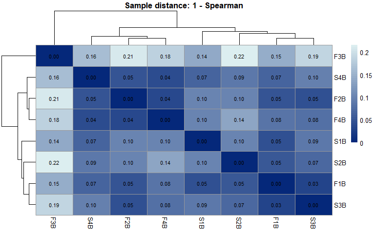

```r
distances <- compute_distance_matrix(normalized,
  use_correlation = TRUE, correlation_method = "spearman",
  plot_heatmap = TRUE, display_numbers = TRUE,
  main_title = "Sample distance: 1 - Spearman")
```

```r
round(distances[1:4, 1:4], 3)
```

```
#>       F1B   F2B   F3B   F4B
#> F1B 0.000 0.051 0.146 0.083
#> F2B 0.051 0.000 0.209 0.037
#> F3B 0.146 0.209 0.000 0.185
#> F4B 0.083 0.037 0.185 0.000
```

For Euclidean comparison of expression magnitudes, use `use_correlation = FALSE, method = "euclidean"`. The matrix is returned whether or not you request a plot. Different metrics respond to different aspects of the data and can produce different sample groupings.

# 5 Explore components: `pca_analysis()`

**Purpose:** compute PCA, explained variance and sample representations. **Input:** `normalized` and aligned metadata. **Output:** a list whose `pca_result` is passed to the next gene-selection stage.

| Parameter | How to choose |
| --- | --- |
| `count_matrix` | Expression matrix. |
| `design_matrix` | Optional metadata in the same order as samples. |
| `color_by`, `shape_by` | Metadata column name or aligned vector; for example, condition for color and batch for shape. |
| `center` | `TRUE` centers each gene for PCA; the default. |
| `scale` | `TRUE` standardizes genes before PCA; default `FALSE`. This changes relative gene weights and may change selection. |
| `plot_2d`, `plot_3d` | Display two- or three-dimensional plots; 3D requires enough components. |
| `plot_cos2` | Display sample representation quality. |
| `plot_corrplot` | `NULL` disables it; `"cos2"`, `"contrib"` or `"coord"` selects the displayed quantity. |
| `gradient_cols` | Colors for the representation-quality plot. |

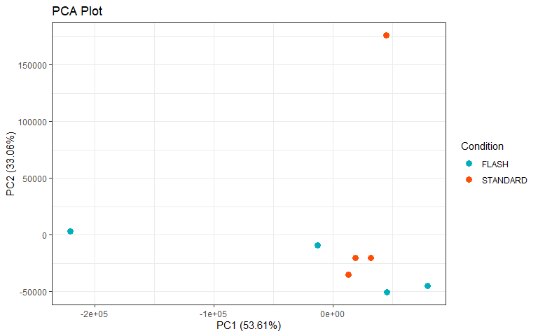

```r
pca <- pca_analysis(normalized, design_matrix = metadata,
  color_by = "Condition", center = TRUE, scale = FALSE,
  plot_2d = TRUE, plot_3d = FALSE)
```

```r
data.frame(PC = seq_along(pca$variance),
  variance_percent = pca$variance,
  cumulative_percent = pca$cumulative_variance)
```

```
#>   PC variance_percent cumulative_percent
#> 1  1     5.361496e+01           53.61496
#> 2  2     3.305670e+01           86.67165
#> 3  3     7.050638e+00           93.72229
#> 4  4     3.256747e+00           96.97904
#> 5  5     1.779174e+00           98.75821
#> 6  6     8.730205e-01           99.63123
#> 7  7     3.687664e-01          100.00000
#> 8  8     1.271158e-30          100.00000
```

```r
head(pca$cos2)
```

```
#>          Dim.1       Dim.2        Dim.3        Dim.4        Dim.5        Dim.6
#> F1B 0.09185423 0.044438953 4.823872e-01 6.743037e-02 1.934221e-01 0.0011180573
#> F2B 0.64790287 0.205792914 6.104939e-03 8.937542e-03 1.251781e-01 0.0044145388
#> F3B 0.99689128 0.000219091 1.510874e-06 4.945621e-04 2.181837e-03 0.0001502598
#> F4B 0.32816790 0.400826009 7.481451e-02 1.112801e-01 2.935818e-02 0.0457112637
#> S1B 0.06151578 0.937538026 6.001301e-04 1.065263e-06 8.595962e-05 0.0001242450
#> S2B 0.05125025 0.057187394 8.505894e-01 2.374039e-02 1.388212e-02 0.0032790250
#>            Dim.7        Dim.8
#> F1B 1.193491e-01 6.760831e-32
#> F2B 1.669131e-03 6.071137e-32
#> F3B 6.145612e-05 1.896983e-32
#> F4B 9.842054e-03 1.563472e-33
#> S1B 1.347939e-04 1.488785e-32
#> S2B 7.139763e-05 2.146179e-33
```

`variance` and `cumulative_variance` are percentages. `eigenvalues` contains eigenvalues; `ind` includes coordinates, contributions and cos². Plots are displayed during the call but are not returned as components of this list.

```r
detailed_pca <- pca_analysis(normalized, design_matrix = metadata,
  color_by = "Condition", plot_cos2 = TRUE, plot_corrplot = "contrib",
  plot_3d = TRUE)
```

# 6 Select genes by PCA: `feature_selection_pca()`

**Purpose:** select genes by absolute PCA loadings. **Input:** `pca$pca_result` and its matching matrix. **Output:** gene identifiers and a reduced matrix. A gene selected in several components appears once; two PCs × twelve genes need not yield 24 distinct genes.

| Parameter | How to choose |
| --- | --- |
| `pca_result` | A `prcomp` object, here `pca$pca_result`. |
| `count_matrix` | Matrix corresponding to the PCA, with matching gene IDs. |
| `num_pcs` | Number of components to consider. |
| `num_genes_per_pc` | Number of genes selected from each component. |
| `select_worst` | `FALSE` selects largest absolute loadings; `TRUE`, smallest. This is not a biological ranking of good/bad genes. |
| `use_last_pcs` | `FALSE` uses the first PCs; `TRUE`, the last PCs. |

```r
pca_selection <- feature_selection_pca(pca$pca_result, normalized,
  num_pcs = 2, num_genes_per_pc = 12,
  select_worst = FALSE, use_last_pcs = FALSE)
length(pca_selection$selected_genes)
```

```
#> [1] 17
```

```r
head(pca_selection$selected_genes)
```

```
#> [1] "ENSMUSG00000001506.11" "ENSMUSG00000029661.17" "ENSMUSG00000051747.17"
#> [4] "ENSMUSG00000064351.1"  "ENSMUSG00000119584.1"  "ENSMUSG00000018593.14"
```

```r
refined <- pca_selection$selected_count_matrix
dim(refined)
```

```
#> [1]  8 17
```

The bundled matrix is already preselected. This step demonstrates how PCA selection works. For your own data, apply it to the full normalized matrix. For example, to select 100 genes from each of four components:

```r
# full_normalized must come from your full normalized matrix, not the reduced example.
full_pca <- pca_analysis(full_normalized, plot_2d = FALSE)
refined_matrix <- feature_selection_pca(full_pca$pca_result, full_normalized,
  num_pcs = 4, num_genes_per_pc = 100)
```

# 7 Prepare classification input: `prepare_input_matrix()`

**Purpose:** transform the sample-by-gene matrix into gene-condition rows with `Gene`, `Rep_1`, `Rep_2`, … and `Condition` columns. **Input:** `refined` and condition metadata. **Output:** a classification table with a `sample_map` attribute linking replicate slots to original sample IDs. Conditions must have equal replicate counts and matching genes.

| Parameter | How to choose |
| --- | --- |
| `count_matrix` | Expression matrix; orientation is determined from the sample identifiers. |
| `design_table` | Metadata table, when using the table interface. |
| `sample_col`, `condition_col` | Sample and condition column names in `design_table`. |
| `sample_vector`, `condition_vector` | Alternative to a table: matching sample-name and condition vectors. |

```r
input <- prepare_input_matrix(refined, design_table = metadata,
  sample_col = "Sample", condition_col = "Condition")
head(input)
```

```
#>                    Gene     Rep_1     Rep_2      Rep_3     Rep_4 Condition
#> 1 ENSMUSG00000001506.11 384193.06 471125.93 232871.887 440277.89     FLASH
#> 2 ENSMUSG00000029661.17 156266.66 194798.07  96022.313 172945.23     FLASH
#> 3 ENSMUSG00000051747.17  63810.53  40864.35 135755.341  49855.48     FLASH
#> 4  ENSMUSG00000064351.1 199799.76 207097.60 272435.043 189968.50     FLASH
#> 5  ENSMUSG00000119584.1  28819.49   8467.30    783.402   1353.44     FLASH
#> 6 ENSMUSG00000018593.14  84595.02 116066.52  60045.458  98089.65     FLASH
```

```r
attr(input, "sample_map")
```

```
#>   Condition Replicate Sample
#> 1     FLASH     Rep_1    F1B
#> 2     FLASH     Rep_2    F2B
#> 3     FLASH     Rep_3    F3B
#> 4     FLASH     Rep_4    F4B
#> 5  STANDARD     Rep_1    S1B
#> 6  STANDARD     Rep_2    S2B
#> 7  STANDARD     Rep_3    S3B
#> 8  STANDARD     Rep_4    S4B
```

Use one metadata interface. The equivalent vector interface is:

```r
input <- prepare_input_matrix(refined,
  sample_vector = metadata$Sample, condition_vector = metadata$Condition)
```

# 8 Classify and resample: `classification_approach_advanced()`

**Purpose:** draw genes and fit algorithms across all allowed replicate partitions. **Input:** `input`. **Output:** models and tables recording scores, genes, partitions, sample identities and fitting failures.

| Parameter | How to choose |
| --- | --- |
| `input_data` | Table returned by `prepare_input_matrix()`. |
| `algorithms` | caret methods such as `"rf"`, `"ranger"` or `"svmLinear2"`; install their model engines. |
| `hyper_params` | `NULL` requests caret-generated grids; otherwise supply named algorithm-specific data frames. RF uses `mtry`. |
| `tune_length` | Requested tuning-grid size when `hyper_params = NULL`; the actual grid depends on the algorithm and available predictors. |
| `store_models` | `FALSE` saves memory by discarding fitted models while retaining scores, genes and selected tuning parameters. |
| `num_resamples` | Number of gene sets to draw; increases the number of fitted models. |
| `num_genes` | Genes drawn per set, from the first condition and matched by identity in the others. |
| `train_percentage` | Fraction of replicates for training; `.75` with four replicates gives three training and one test replicate. |
| `metrics` | Currently only `"Accuracy"` is supported. |
| `summary_stat` | `"median"` or `"mean"` to summarize partition test scores for each resample. |
| `replace_genes` | `TRUE` permits repeated genes, as in the default procedure; `FALSE` requires enough available genes. |
| `parallel` | Allows parallel model training; does not automatically configure a worker cluster. |
| `seed` | Random seed for reproducibility in a compatible recorded environment. |
| `include_gene` | `TRUE` preserves gene identity as a predictor in the default procedure. Setting `FALSE` changes the analysis. |
| `error_handling` | `"stop"` reports the failed fit and stops; `"continue"` records failures and leaves incomplete summaries as `NA`. |

```r
classification <- classification_approach_advanced(input,
  algorithms = "rf", hyper_params = list(rf = data.frame(mtry = c(1, 3))),
  num_resamples = 3, num_genes = 10, train_percentage = .75,
  metrics = "Accuracy", summary_stat = "median", replace_genes = TRUE,
  parallel = FALSE, seed = 123, include_gene = TRUE,
  error_handling = "stop")
classification$partition_table
```

```
#>   Partition_ID      Train_Splits Test_Splits
#> 1  Partition 1 Rep_1,Rep_2,Rep_3       Rep_4
#> 2  Partition 2 Rep_1,Rep_2,Rep_4       Rep_3
#> 3  Partition 3 Rep_1,Rep_3,Rep_4       Rep_2
#> 4  Partition 4 Rep_2,Rep_3,Rep_4       Rep_1
```

```r
head(classification$eval_table)
```

```
#>   algorithm resample data_split   train_partition test_partition train_accuracy
#> 1        rf        1          1 Rep_1,Rep_2,Rep_3          Rep_4              1
#> 2        rf        1          2 Rep_1,Rep_2,Rep_4          Rep_3              1
#> 3        rf        1          3 Rep_1,Rep_3,Rep_4          Rep_2              1
#> 4        rf        1          4 Rep_2,Rep_3,Rep_4          Rep_1              1
#> 5        rf        2          1 Rep_1,Rep_2,Rep_3          Rep_4              1
#> 6        rf        2          2 Rep_1,Rep_2,Rep_4          Rep_3              1
#>   test_accuracy status error summary_test_accuracy
#> 1          0.85     ok  <NA>                  0.55
#> 2          0.25     ok  <NA>                  0.55
#> 3          0.60     ok  <NA>                  0.55
#> 4          0.50     ok  <NA>                  0.55
#> 5          0.75     ok  <NA>                  0.55
#> 6          0.35     ok  <NA>                  0.55
```

```r
classification$status_table
```

```
#>    algorithm resample data_split status error
#> 1         rf        1          1     ok  <NA>
#> 2         rf        1          2     ok  <NA>
#> 3         rf        1          3     ok  <NA>
#> 4         rf        1          4     ok  <NA>
#> 5         rf        2          1     ok  <NA>
#> 6         rf        2          2     ok  <NA>
#> 7         rf        2          3     ok  <NA>
#> 8         rf        2          4     ok  <NA>
#> 9         rf        3          1     ok  <NA>
#> 10        rf        3          2     ok  <NA>
#> 11        rf        3          3     ok  <NA>
#> 12        rf        3          4     ok  <NA>
```

```r
head(classification$gene_ids_table)
```

```
#>              Resample_1           Resample_2            Resample_3
#> 1 ENSMUSG00000057003.13 ENSMUSG00002076161.1 ENSMUSG00000057003.13
#> 2  ENSMUSG00000092341.6 ENSMUSG00000064341.1  ENSMUSG00000064345.1
#> 3 ENSMUSG00000051747.17 ENSMUSG00000064345.1 ENSMUSG00000076617.10
#> 4  ENSMUSG00000064345.1 ENSMUSG00000064367.1  ENSMUSG00000064341.1
#> 5 ENSMUSG00000030730.13 ENSMUSG00000064351.1  ENSMUSG00000064367.1
#> 6  ENSMUSG00000119584.1 ENSMUSG00000092341.6  ENSMUSG00000064367.1
```

**Where results are stored:** `eval_table` records scores by algorithm, resample and partition; `test_eval_table` separates held-out replicates; `partition_table` describes splits; `genes_table` retains legacy positions; `gene_ids_table` stores IDs including repeated draws; `sample_map` identifies samples; `status_table` records successes/failures; `models` stores trained models; `summary_stat` identifies the chosen summary. `tuning_table` records selected tuning parameters and `configuration` records the analysis settings.

Four replicates and `.75` training give four partitions. Three resamples and one algorithm produce twelve partition fits, each with its tuning grid. Increase `num_resamples` to evaluate more gene sets and use `num_genes` to choose their size. Runtime depends on the data, engine and tuning grid.

`mtry` is the number of predictors considered at each RF tree split; it is not the number of genes drawn, which is controlled by `num_genes`. The short `c(1, 3)` grid is suitable for this small teaching example. For multiple engines, provide a grid for each:

```r
install.packages("ranger")
several_engines <- classification_approach_advanced(input,
  algorithms = c("rf", "ranger"),
  hyper_params = list(
    rf = data.frame(mtry = c(1, 3)),
    ranger = expand.grid(mtry = c(1, 3), splitrule = "gini",
      min.node.size = c(1, 3))),
  num_resamples = 3, num_genes = 10, seed = 123)
```

**Interpretation:** training rows represent gene-condition combinations and replicates are predictors. For each held-out replicate, its expression values are repeated into the training-column layout. If several replicates are held out, each is evaluated and their scores are averaged. Internal training retains the default procedure and is not independent validation. Do not present these scores as validated prediction accuracy for unseen patients or unseen genes.

# 9 Check search coverage: `summarize_gene_resampling()`

Three resamples make a quick demonstration. They are not a thorough search: some candidate genes may never be sampled. Inspect this before interpreting selection or increasing the search size.

```r
diagnostics <- summarize_gene_resampling(classification)
diagnostics$coverage_table
```

```
#>    algorithm total_resamples evaluated_resamples qualifying_resamples
#> rf        rf               3                   3                   NA
#>    gene_universe_size sampled_genes sampling_coverage evaluated_genes
#> rf                 17            15         0.8823529              15
#>    evaluated_coverage min_resamples_per_gene max_resamples_per_gene
#> rf          0.8823529                      0                      3
```

```r
head(diagnostics$gene_table)
```

```
#>      algorithm               gene_id resamples_sampled resamples_evaluated
#> rf.1        rf ENSMUSG00000001506.11                 0                   0
#> rf.2        rf ENSMUSG00000029661.17                 1                   1
#> rf.3        rf ENSMUSG00000051747.17                 1                   1
#> rf.4        rf  ENSMUSG00000064351.1                 1                   1
#> rf.5        rf  ENSMUSG00000119584.1                 1                   1
#> rf.6        rf ENSMUSG00000018593.14                 1                   1
#>      resamples_qualified sampling_fraction qualification_fraction
#> rf.1                  NA         0.0000000                     NA
#> rf.2                  NA         0.3333333                     NA
#> rf.3                  NA         0.3333333                     NA
#> rf.4                  NA         0.3333333                     NA
#> rf.5                  NA         0.3333333                     NA
#> rf.6                  NA         0.3333333                     NA
#>      qualified_presence_fraction
#> rf.1                          NA
#> rf.2                          NA
#> rf.3                          NA
#> rf.4                          NA
#> rf.5                          NA
#> rf.6                          NA
```

| Parameter | How to choose |
| --- | --- |
| `classification_result` | Complete classification object, preserving its gene-universe metadata. |
| `cutoff` | Minimum resample score; `NULL` reports coverage without defining qualifying sets. |
| `metric_column` | A resample summary such as `"summary_test_accuracy"`, not a varying partition score. |
| `algorithm` | One or more engines to inspect; `NULL` reports each separately. |
| `gene_universe` | Complete candidate-gene IDs if metadata was lost during export. Include unsampled genes. |

`sampling_coverage` is the fraction of candidate genes drawn at least once. `min_resamples_per_gene` reveals genes receiving little or no exploration. Repeated draws within one resample count once. `qualification_fraction` is the fraction of successfully evaluated sets containing a gene that meet the cutoff; it describes group recurrence and does not establish gene importance or statistical significance. No qualifying sets is a valid result.

For a larger search with automatic tuning and reduced memory use:

```r
larger <- classification_approach_advanced(input, algorithms = "rf",
  hyper_params = NULL, tune_length = 10, num_resamples = 100,
  num_genes = 10, seed = 123, store_models = FALSE)
coverage <- summarize_gene_resampling(larger)
coverage$coverage_table
```

Choose the cutoff and gene-set sizes for your scientific question. Increasing resampling explores more combinations; it does not guarantee signal recovery. Changing the tuning grid can change scores and selected sets. To retain an existing analysis, keep its explicit grid, seed and selection settings.

# 10 Select genes from resamples: `genes_from_classification_results()`

**Purpose:** select resamples by explicit IDs or a score threshold and extract their genes. **Input:** classification tables and `refined`. **Output:** selected genes, a filtered matrix and an optional score plot.

| Parameter | How to choose |
| --- | --- |
| `eval_table`, `genes_table` | Tables returned by classification. |
| `count_matrix` | Sample-by-gene matrix to filter, here `refined`. |
| `resamples` | Explicit IDs, such as `c(1, 3)`; when supplied, these determine selection. |
| `cutoff`, `metric_column` | Alternative to IDs: select resamples whose metric is **at least** the threshold, for example `"summary_test_accuracy"`. |
| `selection_mode` | `"unique"` returns the union of genes; `"intersect"` retains genes present in all selected resamples. |
| `algorithm` | Restrict selection to an algorithm; `NULL` uses the union of qualifying IDs across algorithms. |
| `gene_ids_table` | Explicit ID table; especially useful after CSV export/reimport. |
| `partition_table` | Identifies partitions in the plot colors. |
| `plot_type` | `"summary"` shows summary scores; `"all"`, partition scores; `"both"`, both. |
| `plot_resamples_only` | `TRUE` shows selected IDs only; `FALSE`, all resamples. |
| `return_plot` | `TRUE` displays and returns a plot; `FALSE` only selects genes. |
| `hline_yintercept`, `hline_color` | Value and color of the visual reference line; this line does not select genes. |
| `median_color` | Summary-score color, including when `summary_stat = "mean"`. |
| `test_colors`, `show_legend` | Partition colors and legend visibility; provide enough colors for displayed partitions. |

For this short example, select the resample with the largest recorded summary. This keeps relationship figures small; it is not a significance test or an independent assessment of discovery performance.

```r
scores <- unique(classification$eval_table[,
  c("algorithm", "resample", "summary_test_accuracy")])
scores
```

```
#>   algorithm resample summary_test_accuracy
#> 1        rf        1                 0.550
#> 5        rf        2                 0.550
#> 9        rf        3                 0.625
```

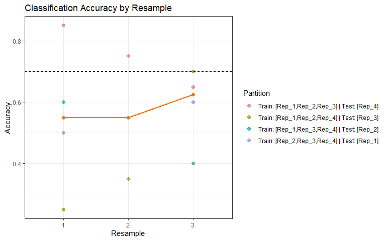

```r
chosen_id <- scores$resample[which.max(scores$summary_test_accuracy)]
selection <- genes_from_classification_results(classification$eval_table,
  classification$genes_table, refined, resamples = chosen_id,
  gene_ids_table = classification$gene_ids_table,
  partition_table = classification$partition_table, selection_mode = "unique",
  plot_type = "both", plot_resamples_only = FALSE, return_plot = TRUE)
```

```r
selection$selected_resamples
```

```
#> [1] 3
```

```r
selection$selected_gene_ids
```

```
#> [1] "ENSMUSG00000057003.13" "ENSMUSG00000064345.1"  "ENSMUSG00000076617.10"
#> [4] "ENSMUSG00000064341.1"  "ENSMUSG00000064367.1"  "ENSMUSG00000018593.14"
#> [7] "ENSMUSG00000029661.17"
```

```r
selected_expression <- selection$filtered_matrix
dim(selected_expression)
```

```
#> [1] 8 7
```

To use a study-specific score threshold and retain genes present in all selected sets, use the following alternative. The value 0.70 illustrates the argument; it is not a recommended universal threshold. Define your criterion before assessing discovery performance and handle an empty result explicitly.

```r
score_cutoff <- .70
qualifying <- scores$resample[scores$summary_test_accuracy >= score_cutoff]
if (length(qualifying)) {
threshold_selection <- genes_from_classification_results(classification$eval_table,
  classification$genes_table, refined, cutoff = score_cutoff,
  metric_column = "summary_test_accuracy", selection_mode = "intersect",
  algorithm = "rf", gene_ids_table = classification$gene_ids_table,
  partition_table = classification$partition_table,
  plot_type = "both", hline_yintercept = score_cutoff)
} else {
  message("No gene sets meet the chosen cutoff.")
}
```

To continue with that choice, assign `selected_expression <- threshold_selection$filtered_matrix`. No resample may meet the cutoff, or the gene intersection may be empty. Inspect scores and selected sets before proceeding. Do not lower thresholds solely to force a nonempty result. Union/intersection changes the gene universe downstream. CSV loses R attributes: save `gene_ids_table` explicitly or use RDS to preserve the full classification object and its mapping.

# 11 Correlate each gene across conditions: `acc_analysis()`

**Purpose:** correlate each gene’s two condition-specific replicate vectors. **Input:** `selected_expression`, with samples in two ordered blocks. **Output:** a table if `plot = FALSE`; a list with `results` and `plot` if `TRUE`.

| Parameter | How to choose |
| --- | --- |
| `data` | Sample-by-gene matrix. |
| `condition_split` | Endpoints of the two blocks: `c(4, 8)` means rows 1–4 and 5–8, not just rows 4 and 8. |
| `method` | `"spearman"`, `"pearson"` or `"kendall"`; default Spearman. |
| `plot` | Also generate a bar plot. |
| `color` | One color for all bars or two for negative/positive correlations. |
| `orientation` | `"vertical"` or `"horizontal"`. |
| `show_legend`, `rotate_labels` | Legend visibility and rotated labels on vertical plots. |
| `title`, `xlab`, `ylab` | Plot title and axis labels. |

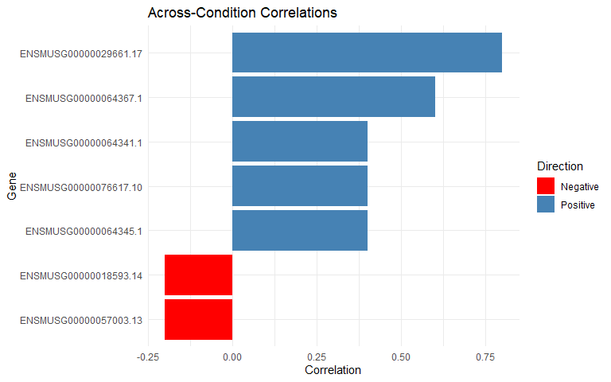

```r
stopifnot(identical(metadata$Condition,
  rep(c("FLASH", "STANDARD"), each = 4)))
split <- c(4, 8)
acc <- acc_analysis(selected_expression, condition_split = split,
  method = "spearman", plot = TRUE, orientation = "horizontal")
```

```r
acc$results
```

```
#>                    Gene Correlation Direction
#> 1 ENSMUSG00000057003.13        -0.2  Negative
#> 2 ENSMUSG00000018593.14        -0.2  Negative
#> 3  ENSMUSG00000064345.1         0.4  Positive
#> 4 ENSMUSG00000076617.10         0.4  Positive
#> 5  ENSMUSG00000064341.1         0.4  Positive
#> 6  ENSMUSG00000064367.1         0.6  Positive
#> 7 ENSMUSG00000029661.17         0.8  Positive
```

ACC aligns replicates **by position**: first with first, second with second, and so on. This does not establish biological pairing. The example illustrates an exploratory vector comparison; without justified pairing, do not interpret it as correlation of biologically paired observations. For your own data, arrange and document sample order before calling the function.

# 12 Correlate genes within each condition: `icc_analysis()`

**Purpose:** compute gene-by-gene correlations separately within each condition. **Input:** the same `selected_expression`. **Output:** a list with two correlation matrices used by `icc_difference()`.

| Parameter | How to choose |
| --- | --- |
| `data`, `condition_split` | Matrix and endpoints of the two condition blocks. |
| `method` | `"spearman"`, `"pearson"` or `"kendall"`. |
| `plot` | Display both correlograms. |
| `colors` | Colors for negative, zero and positive correlations. |
| `plot_type` | `"lower"`, `"upper"` or `"full"` selects the displayed triangle or full matrix. |
| `show_coef` | Display coefficients in cells. |
| `tl.cex`, `number.cex` | Font sizes for gene names and coefficients. |
| `order` | Visual ordering: `"AOE"`, `"FPC"`, `"hclust"` or `"alphabet"`. |

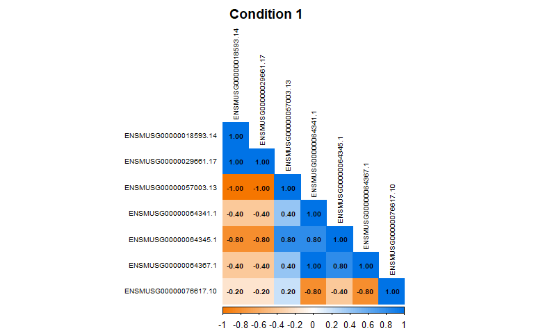

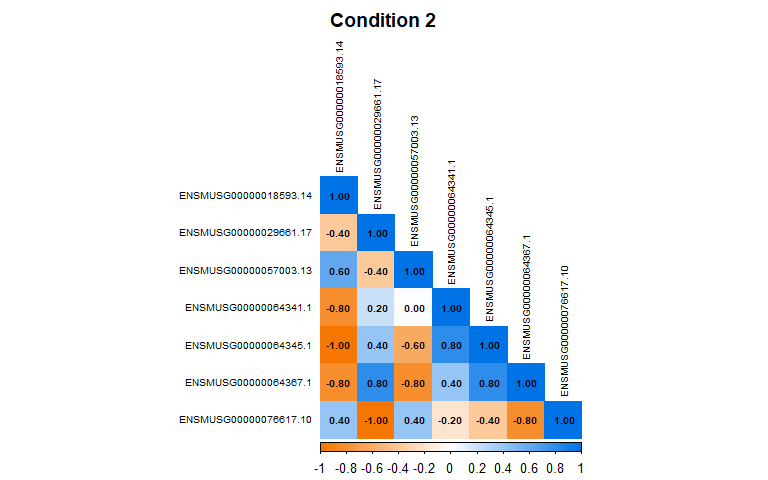

```r
icc <- icc_analysis(selected_expression, condition_split = split,
  method = "spearman", plot = TRUE, plot_type = "lower",
  show_coef = TRUE, tl.cex = .6, number.cex = .6, order = "alphabet")
```

```r
round(icc$correlation_matrix_cond1[1:4, 1:4], 2)
```

```
#>                       ENSMUSG00000057003.13 ENSMUSG00000064345.1
#> ENSMUSG00000057003.13                   1.0                  0.8
#> ENSMUSG00000064345.1                    0.8                  1.0
#> ENSMUSG00000076617.10                   0.2                 -0.4
#> ENSMUSG00000064341.1                    0.4                  0.8
#>                       ENSMUSG00000076617.10 ENSMUSG00000064341.1
#> ENSMUSG00000057003.13                   0.2                  0.4
#> ENSMUSG00000064345.1                   -0.4                  0.8
#> ENSMUSG00000076617.10                   1.0                 -0.8
#> ENSMUSG00000064341.1                   -0.8                  1.0
```

```r
round(icc$correlation_matrix_cond2[1:4, 1:4], 2)
```

```
#>                       ENSMUSG00000057003.13 ENSMUSG00000064345.1
#> ENSMUSG00000057003.13                   1.0                 -0.6
#> ENSMUSG00000064345.1                   -0.6                  1.0
#> ENSMUSG00000076617.10                   0.4                 -0.4
#> ENSMUSG00000064341.1                    0.0                  0.8
#>                       ENSMUSG00000076617.10 ENSMUSG00000064341.1
#> ENSMUSG00000057003.13                   0.4                  0.0
#> ENSMUSG00000064345.1                   -0.4                  0.8
#> ENSMUSG00000076617.10                   1.0                 -0.2
#> ENSMUSG00000064341.1                   -0.2                  1.0
```

The first matrix corresponds to FLASH and the second to STANDARD in this sample order. Correlations range from −1 to 1. Constant genes can produce `NA`; four samples per condition give exploratory estimates sensitive to individual observations. Visual ordering does not change calculated coefficients.

# 13 Compare correlations: `icc_difference()`

**Purpose:** calculate `abs(cor_cond1 - cor_cond2)` for matching gene pairs. **Input:** `icc`. **Output:** a complete matrix, a pair table and optional heatmap. Absolute differences range from 0 to 2. They do not show which condition has the larger signed correlation; consult both ICC matrices for that information.

| Parameter | How to choose |
| --- | --- |
| `icc_result` | List returned by ICC analysis. |
| `cutoff` | `NULL` retains all differences; a value from 0 to 2 retains differences **at least** that value in the table. |
| `unique_pairs` | `TRUE` returns each undirected pair once, without the diagonal; `FALSE` includes self-pairs and both directions, including both directions and the diagonal. |
| `plot` | Draw the heatmap. |
| `heatmap_colors`, `heatmap_breaks` | Color-palette function and interval boundaries. |
| `show_rownames`, `show_colnames` | Display gene labels. |
| `cluster_rows`, `cluster_cols` | Cluster rows and columns in the figure. |
| `fontsize` | Base heatmap text size. |

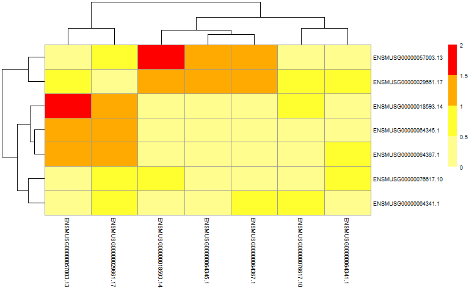

```r
differences <- icc_difference(icc, cutoff = NULL,
  unique_pairs = TRUE, plot = TRUE, fontsize = 7)
```

```r
head(differences$difference_table)
```

```
#>                   Gene1                 Gene2 Corr_Condition1 Corr_Condition2
#> 1 ENSMUSG00000057003.13 ENSMUSG00000018593.14            -1.0             0.6
#> 2 ENSMUSG00000057003.13  ENSMUSG00000064345.1             0.8            -0.6
#> 3 ENSMUSG00000018593.14 ENSMUSG00000029661.17             1.0            -0.4
#> 4 ENSMUSG00000057003.13  ENSMUSG00000064367.1             0.4            -0.8
#> 5  ENSMUSG00000064345.1 ENSMUSG00000029661.17            -0.8             0.4
#> 6  ENSMUSG00000064367.1 ENSMUSG00000029661.17            -0.4             0.8
#>   Abs_Difference
#> 1            1.6
#> 2            1.4
#> 3            1.4
#> 4            1.2
#> 5            1.2
#> 6            1.2
```

```r
dim(differences$absolute_diff_matrix)
```

```
#> [1] 7 7
```

To retain changes of at least 1:

```r
large_changes <- icc_difference(icc, cutoff = 1, plot = FALSE)
head(large_changes$difference_table)
```

```
#>                   Gene1                 Gene2 Corr_Condition1 Corr_Condition2
#> 1 ENSMUSG00000057003.13 ENSMUSG00000018593.14            -1.0             0.6
#> 2 ENSMUSG00000057003.13  ENSMUSG00000064345.1             0.8            -0.6
#> 3 ENSMUSG00000018593.14 ENSMUSG00000029661.17             1.0            -0.4
#> 4 ENSMUSG00000057003.13  ENSMUSG00000064367.1             0.4            -0.8
#> 5  ENSMUSG00000064345.1 ENSMUSG00000029661.17            -0.8             0.4
#> 6  ENSMUSG00000064367.1 ENSMUSG00000029661.17            -0.4             0.8
#>   Abs_Difference
#> 1            1.6
#> 2            1.4
#> 3            1.4
#> 4            1.2
#> 5            1.2
#> 6            1.2
```

The filter affects the table and masks the plotted cells; `absolute_diff_matrix` retains the complete matrix. A correlation-difference cutoff is not a statistical-significance threshold.

# 14 Mine rules for each condition: `mine_gene_associations()`

**Purpose:** find associations between gene-expression states within each condition. **Input:** `selected_expression` and its condition-specific row indices. **Output:** `transactions`, an arules `rules` object, `rules_df`, and a `plot` object when generated.

| Parameter | How to choose |
| --- | --- |
| `data` | Sample-by-gene matrix. Numeric columns are discretized; factor columns allow predefined states. |
| `condition_rows` | Sample indices: `1:4` for FLASH and `5:8` for STANDARD here. |
| `method` | `"apriori"` or `"fpgrowth"`; the latter additionally requires the optional `fim4r` backend. |
| `supp` | Minimum support: fraction of samples containing all rule items. With four samples, `.5` requires at least two. |
| `conf` | Minimum confidence: consequent frequency among transactions containing the antecedent. |
| `lift` | `NULL` disables lift filtering; a numeric value sets minimum lift. Lift is not a p-value. |
| `minlen`, `maxlen` | Minimum/maximum total items across both rule sides. `maxlen = 2` restricts to short rules. |
| `target_genes` | Exact gene names of interest; `NULL` does not restrict them. |
| `search_type` | Match targets in `"lhs"` (antecedent), `"rhs"` (consequent) or `"both"`. |
| `plot_type` | `"scatter"`, `"graph"`, `"paracoord"` or `"grouped"`. |
| `interactive` | Enable supported interactive visualizations; `FALSE` is suitable for static tutorials/export. |
| `top_n` | Limits plotted rules, not all returned rules. |
| `measure`, `shading` | Measure and shading for grouped plots, such as support and lift. |
| `color`, `lhs_max`, `rhs_max` | Color and grouped-plot controls. |

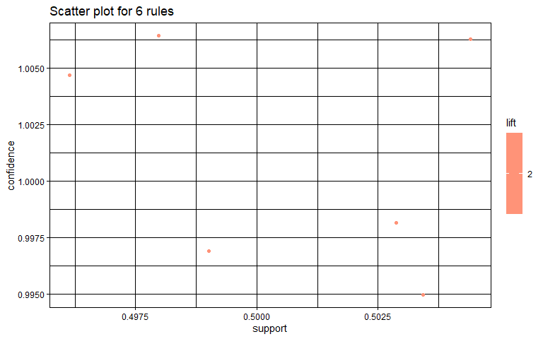

```r
flash_rules <- mine_gene_associations(selected_expression, condition_rows = 1:4,
  method = "apriori", supp = .5, conf = .8, minlen = 2, maxlen = 2,
  plot_type = "scatter", interactive = FALSE, top_n = 20)
```

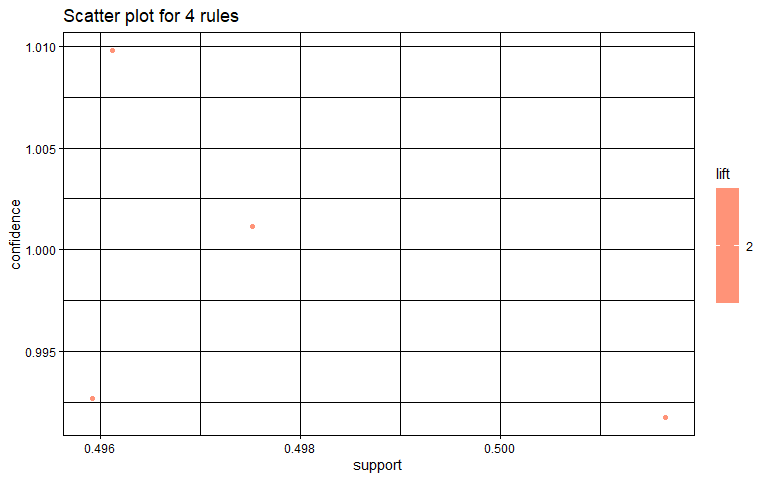

```r
standard_rules <- mine_gene_associations(selected_expression, condition_rows = 5:8,
  method = "apriori", supp = .5, conf = .8, minlen = 2, maxlen = 2,
  plot_type = "scatter", interactive = FALSE, top_n = 20)
```

```r
length(flash_rules$rules)
```

```
#> [1] 6
```

```r
length(standard_rules$rules)
```

```
#> [1] 4
```

```r
head(flash_rules$rules_df)
```

```
#>                                           LHS
#> 1  {ENSMUSG00000057003.13=[1.7e+04,3.45e+04]}
#> 2  {ENSMUSG00000064345.1=[4.09e+04,6.52e+04]}
#> 3 {ENSMUSG00000029661.17=[1.73e+05,1.95e+05]}
#> 4 {ENSMUSG00000018593.14=[9.81e+04,1.16e+05]}
#> 5  {ENSMUSG00000064367.1=[7.04e+04,9.91e+04]}
#> 6   {ENSMUSG00000064341.1=[7.2e+04,1.04e+05]}
#>                                           RHS support confidence coverage lift
#> 1  {ENSMUSG00000064345.1=[4.09e+04,6.52e+04]}     0.5          1      0.5    2
#> 2  {ENSMUSG00000057003.13=[1.7e+04,3.45e+04]}     0.5          1      0.5    2
#> 3 {ENSMUSG00000018593.14=[9.81e+04,1.16e+05]}     0.5          1      0.5    2
#> 4 {ENSMUSG00000029661.17=[1.73e+05,1.95e+05]}     0.5          1      0.5    2
#> 5   {ENSMUSG00000064341.1=[7.2e+04,1.04e+05]}     0.5          1      0.5    2
#> 6  {ENSMUSG00000064367.1=[7.04e+04,9.91e+04]}     0.5          1      0.5    2
#>   count
#> 1     2
#> 2     2
#> 3     2
#> 4     2
#> 5     2
#> 6     2
```

```r
head(standard_rules$rules_df)
```

```
#>                                           LHS
#> 1 {ENSMUSG00000057003.13=[1.79e+04,2.65e+04]}
#> 2 {ENSMUSG00000018593.14=[9.74e+04,1.01e+05]}
#> 3  {ENSMUSG00000064367.1=[7.06e+04,8.89e+04]}
#> 4   {ENSMUSG00000064345.1=[4.17e+04,5.4e+04]}
#>                                           RHS support confidence coverage lift
#> 1 {ENSMUSG00000018593.14=[9.74e+04,1.01e+05]}     0.5          1      0.5    2
#> 2 {ENSMUSG00000057003.13=[1.79e+04,2.65e+04]}     0.5          1      0.5    2
#> 3   {ENSMUSG00000064345.1=[4.17e+04,5.4e+04]}     0.5          1      0.5    2
#> 4  {ENSMUSG00000064367.1=[7.06e+04,8.89e+04]}     0.5          1      0.5    2
#>   count
#> 1     2
#> 2     2
#> 3     2
#> 4     2
```

```r
head(arules::itemLabels(flash_rules$transactions))
```

```
#> [1] "ENSMUSG00000057003.13=[7.36e+03,1.18e+04)"
#> [2] "ENSMUSG00000057003.13=[1.18e+04,1.7e+04)"
#> [3] "ENSMUSG00000057003.13=[1.7e+04,3.45e+04]"
#> [4] "ENSMUSG00000064345.1=[3.48e+04,4.07e+04)"
#> [5] "ENSMUSG00000064345.1=[4.07e+04,4.09e+04)"
#> [6] "ENSMUSG00000064345.1=[4.09e+04,6.52e+04]"
```

A rule `A=state1 => B=state2` associates observed states. Support measures co-occurrence, confidence measures conditional frequency, and lift compares that frequency with the consequent’s prevalence. The arrow does not establish direct regulation or causality. A warning that `maxlen = 2` stopped longer patterns reports the requested restriction rather than a failed fit.

To focus on a gene in the consequent, use its exact name with `target_genes = "gene_name", search_type = "rhs"`. Increasing `maxlen` allows longer rules and may greatly increase their number. For a static network, choose `plot_type = "graph", interactive = FALSE`. Zero rules under the selected filters is a valid result.

```r
target_rules <- mine_gene_associations(selected_expression, 1:4,
  target_genes = colnames(selected_expression)[1], search_type = "rhs",
  supp = .5, conf = .8, maxlen = 2, lift = 1,
  plot_type = "graph", interactive = FALSE)
```

**State definitions:** by default, numeric values are discretized separately within each condition. Identical bin labels need not have identical numerical boundaries. For comparable states, define cut points before splitting conditions and supply factor columns. This optional example shares each gene’s global median between conditions:

```r
# Alternative state definition; changes the mined rules.
states <- as.data.frame(lapply(selected_expression, function(x) {
  state <- ifelse(x <= median(x), "low", "high")
  factor(state, levels = c("low", "high"))
}))
rownames(states) <- rownames(selected_expression)
flash_states <- mine_gene_associations(states, 1:4, maxlen = 2,
  interactive = FALSE)
standard_states <- mine_gene_associations(states, 5:8, maxlen = 2,
  interactive = FALSE)
```

These cut points illustrate customization. Choose shared state definitions that are appropriate for your data and biological question.

# 15 Compare rules: `compare_gene_rules()`

**Purpose:** identify shared and condition-specific rules and display their relationships. **Input:** the two `rules_df` tables. **Output:** rule tables, clusters, plot objects and graph objects.

| Parameter | How to choose |
| --- | --- |
| `rules_df1`, `rules_df2` | Rule tables containing `LHS` and `RHS`. |
| `condition_names` | Two names matching the order of the tables. |
| `comparison` | `"genes"` compares complete gene sets on both sides, ignoring states; `"items"` includes expression states in rule identity. |
| `layout_type` | `"linear"` draws arcs; `"fr"` uses a force-directed layout. |
| `plot` | Display shared and condition-specific rule graphs. |

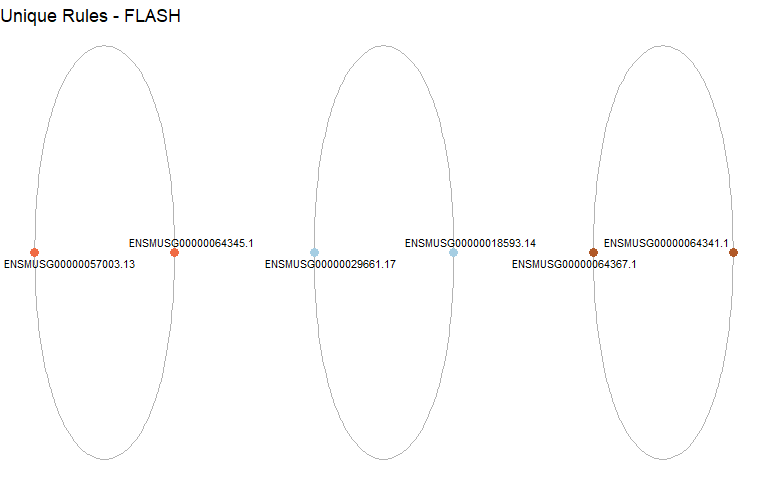

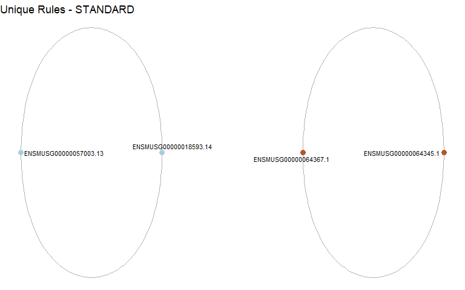

```r
comparison <- compare_gene_rules(flash_rules$rules_df,
  standard_rules$rules_df, condition_names = c("FLASH", "STANDARD"),
  comparison = "genes", layout_type = "linear", plot = TRUE)
```

```r
comparison$shared_rules
```

```
#> [1] LHS RHS
#> <0 rows> (or 0-length row.names)
```

```r
head(comparison$unique_rules_condition1)
```

```
#>                                                                 LHS
#> {ENSMUSG00000057003.13=[1.7e+04,3.45e+04]}  {ENSMUSG00000057003.13}
#> {ENSMUSG00000064345.1=[4.09e+04,6.52e+04]}   {ENSMUSG00000064345.1}
#> {ENSMUSG00000029661.17=[1.73e+05,1.95e+05]} {ENSMUSG00000029661.17}
#> {ENSMUSG00000018593.14=[9.81e+04,1.16e+05]} {ENSMUSG00000018593.14}
#> {ENSMUSG00000064367.1=[7.04e+04,9.91e+04]}   {ENSMUSG00000064367.1}
#> {ENSMUSG00000064341.1=[7.2e+04,1.04e+05]}    {ENSMUSG00000064341.1}
#>                                                                 RHS
#> {ENSMUSG00000057003.13=[1.7e+04,3.45e+04]}   {ENSMUSG00000064345.1}
#> {ENSMUSG00000064345.1=[4.09e+04,6.52e+04]}  {ENSMUSG00000057003.13}
#> {ENSMUSG00000029661.17=[1.73e+05,1.95e+05]} {ENSMUSG00000018593.14}
#> {ENSMUSG00000018593.14=[9.81e+04,1.16e+05]} {ENSMUSG00000029661.17}
#> {ENSMUSG00000064367.1=[7.04e+04,9.91e+04]}   {ENSMUSG00000064341.1}
#> {ENSMUSG00000064341.1=[7.2e+04,1.04e+05]}    {ENSMUSG00000064367.1}
```

```r
head(comparison$unique_rules_condition2)
```

```
#>                                                                 LHS
#> {ENSMUSG00000057003.13=[1.79e+04,2.65e+04]} {ENSMUSG00000057003.13}
#> {ENSMUSG00000018593.14=[9.74e+04,1.01e+05]} {ENSMUSG00000018593.14}
#> {ENSMUSG00000064367.1=[7.06e+04,8.89e+04]}   {ENSMUSG00000064367.1}
#> {ENSMUSG00000064345.1=[4.17e+04,5.4e+04]}    {ENSMUSG00000064345.1}
#>                                                                 RHS
#> {ENSMUSG00000057003.13=[1.79e+04,2.65e+04]} {ENSMUSG00000018593.14}
#> {ENSMUSG00000018593.14=[9.74e+04,1.01e+05]} {ENSMUSG00000057003.13}
#> {ENSMUSG00000064367.1=[7.06e+04,8.89e+04]}   {ENSMUSG00000064345.1}
#> {ENSMUSG00000064345.1=[4.17e+04,5.4e+04]}    {ENSMUSG00000064367.1}
```

`clusters` stores gene groups; `plots` stores figures; `graphs` stores networks; `original_rules` preserves the input tables. Support, confidence and lift do not define rule identity, so shared rules can have different metrics in the two conditions. For multiple genes on a rule side, the graph projects links between genes while the original rule retains the complete itemset.

To require matching expression states:

```r
item_comparison <- compare_gene_rules(flash_rules$rules_df,
  standard_rules$rules_df, condition_names = c("FLASH", "STANDARD"),
  comparison = "items", plot = FALSE)
nrow(item_comparison$shared_rules)
```

```
#> [1] 0
```

Interpret this option together with state definitions. The shared-cut-point example above gives common meanings to state labels.

# 16 Save results and resume later

The workflow creates a separate object for every stage. Save R objects to preserve attributes, identifiers and models; use CSV for inspecting tables. The following block uses a temporary folder during manual construction. For your project, replace it with a permanent directory such as `"my_results"`.

```r
directory <- file.path(tempdir(), "MettleRNASeq_step_by_step")
dir.create(directory, recursive = TRUE, showWarnings = FALSE)
saveRDS(list(normalized = normalized, metadata = metadata,
  distances = distances, pca = pca, pca_selection = pca_selection,
  input = input, classification = classification, selection = selection,
  acc = acc, icc = icc, differences = differences,
  flash_rules = flash_rules, standard_rules = standard_rules,
  comparison = comparison), file.path(directory, "full_workflow.rds"))
write.csv(classification$eval_table, file.path(directory, "classification.csv"),
  row.names = FALSE)
write.csv(classification$gene_ids_table, file.path(directory, "sampled_gene_ids.csv"),
  row.names = FALSE)
write.csv(selected_expression, file.path(directory, "selected_expression.csv"))
write.csv(acc$results, file.path(directory, "acc.csv"), row.names = FALSE)
write.csv(icc$correlation_matrix_cond1, file.path(directory, "icc_FLASH.csv"))
write.csv(icc$correlation_matrix_cond2, file.path(directory, "icc_STANDARD.csv"))
write.csv(differences$difference_table, file.path(directory, "icc_differences.csv"),
  row.names = FALSE)
write.csv(flash_rules$rules_df, file.path(directory, "FLASH_rules.csv"),
  row.names = FALSE)
write.csv(standard_rules$rules_df, file.path(directory, "STANDARD_rules.csv"),
  row.names = FALSE)
write.csv(comparison$shared_rules, file.path(directory, "shared_rules.csv"),
  row.names = FALSE)
write.csv(comparison$unique_rules_condition1,
  file.path(directory, "unique_FLASH_rules.csv"), row.names = FALSE)
write.csv(comparison$unique_rules_condition2,
  file.path(directory, "unique_STANDARD_rules.csv"), row.names = FALSE)
capture.output(sessionInfo(), file = file.path(directory, "sessionInfo.txt"))
list.files(directory)
```

```
#>  [1] "FLASH_rules.csv"           "STANDARD_rules.csv"
#>  [3] "acc.csv"                   "classification.csv"
#>  [5] "full_workflow.rds"         "icc_FLASH.csv"
#>  [7] "icc_STANDARD.csv"          "icc_differences.csv"
#>  [9] "sampled_gene_ids.csv"      "selected_expression.csv"
#> [11] "sessionInfo.txt"           "shared_rules.csv"
#> [13] "unique_FLASH_rules.csv"    "unique_STANDARD_rules.csv"
```

For returned ggplots, use `ggplot2::ggsave()`; for numeric matrices, use `write.csv()`. To capture all static plots from a run, open `pdf("figures.pdf", width = 10, height = 7)` before plotting stages and call `dev.off()` afterward. Interactive plots require their own export method and are not automatically included in that PDF.

```r
stored <- readRDS(file.path(directory, "full_workflow.rds"))
stored$selection$selected_gene_ids
ggplot2::ggsave(file.path(directory, "accuracies.png"),
  plot = selection$plot, width = 8, height = 5, dpi = 300)
ggplot2::ggsave(file.path(directory, "acc.png"),
  plot = acc$plot, width = 8, height = 5, dpi = 300)
```

# 17 Full reference and troubleshooting

Parameter descriptions follow the package implementation. For example, `method = "scale"` scales values without centering; it does not produce z-scores.

Each function also has conventional R documentation with **Usage, Arguments, Value and Examples**. In RStudio, open it with `?function_name`:

```r
?normalize_count_matrix
?classification_approach_advanced
?mine_gene_associations
browseVignettes("MettleRNASeq")
```

| Situation | What to check |
| --- | --- |
| Metadata and matrix do not match | Exact unique names, metadata row order, and samples removed during filtering. |
| No genes remain after normalization | Raw input values, `min_count`, `group_size` and constant genes. |
| Classification fails | Reported algorithm/resample/partition, installed engine, valid tuning grid and `status_table`. |
| No genes remain after selection | Selected IDs, cutoff, union/intersection and recorded scores. |
| Correlation is `NA` | Constant genes, too few observations or unsuitable input; do not automatically replace with zero. |
| No rules | Support, confidence, lift, rule length and target filters; an empty set can be valid. |
| Too many rules or slow mining | Gene universe, state definitions, thresholds and `maxlen`; `top_n` only reduces the plot. |
| Different results after changing options | Normalization, PCA centering/scaling, PCs, gene draws, engine/grid, union/intersection and states are analytical choices. |

## 17.1 Function signatures and installed default values

The following signatures are obtained from the installed package while building this manual. Arguments without defaults must be supplied. Consult the respective stage above for guidance; you need not repeat arguments whose defaults you want.

### 17.1.1 normalize_count_matrix

```r
function (count_matrix, remove_low_variance = TRUE, min_count = 10,
    group_size = 4, method = "TMM")
```

### 17.1.2 compute_distance_matrix

```r
function (count_matrix, use_correlation = FALSE, method = "euclidean",
    correlation_method = "spearman", plot_heatmap = TRUE, cluster_rows = TRUE,
    cluster_cols = TRUE, clustering_method = "complete", display_numbers = FALSE,
    number_color = "black", color_palette = c("#05287A", "#DCEEF0"),
    breaks = 50, main_title = NULL)
```

### 17.1.3 pca_analysis

```r
function (count_matrix, design_matrix = NULL, color_by = NULL,
    shape_by = NULL, center = TRUE, scale = FALSE, plot_cos2 = FALSE,
    plot_corrplot = NULL, plot_2d = TRUE, plot_3d = FALSE, gradient_cols = c("#00AFBB",
        "#E7B800", "#FC4E07"))
```

### 17.1.4 feature_selection_pca

```r
function (pca_result, count_matrix, num_pcs = 3, num_genes_per_pc = 100,
    select_worst = FALSE, use_last_pcs = FALSE)
```

### 17.1.5 prepare_input_matrix

```r
function (count_matrix, design_table = NULL, sample_col = NULL,
    condition_col = NULL, sample_vector = NULL, condition_vector = NULL)
```

### 17.1.6 classification_approach_advanced

```r
function (input_data, algorithms, hyper_params = NULL, num_resamples,
    num_genes, train_percentage = 0.75, metrics = "Accuracy",
    summary_stat = "median", replace_genes = TRUE, parallel = FALSE,
    seed = 123, include_gene = TRUE, error_handling = c("stop",
        "continue"), tune_length = 10L, store_models = TRUE)
```

### 17.1.7 summarize_gene_resampling

```r
function (classification_result, cutoff = NULL, metric_column = "summary_test_accuracy",
    algorithm = NULL, gene_universe = NULL)
```

### 17.1.8 genes_from_classification_results

```r
function (eval_table, genes_table, count_matrix, resamples = NULL,
    cutoff = NULL, metric_column = "summary_test_accuracy", selection_mode = "unique",
    partition_table = NULL, plot_type = "summary", plot_resamples_only = TRUE,
    return_plot = TRUE, hline_yintercept = 0.7, hline_color = "black",
    median_color = "#f57600", test_colors = NULL, show_legend = TRUE,
    algorithm = NULL, gene_ids_table = NULL)
```

### 17.1.9 acc_analysis

```r
function (data, condition_split, method = "spearman", plot = FALSE,
    color = c("red", "steelblue"), orientation = c("vertical",
        "horizontal"), show_legend = TRUE, rotate_labels = TRUE,
    title = "Across-Condition Correlations", xlab = "Gene", ylab = "Correlation")
```

### 17.1.10 icc_analysis

```r
function (data, condition_split, method = "spearman", plot = FALSE,
    colors = c("#f57600", "white", "#0073e6"), plot_type = c("lower",
        "upper", "full"), show_coef = FALSE, tl.cex = 0.7, number.cex = 0.7,
    order = c("AOE", "FPC", "hclust", "alphabet"))
```

### 17.1.11 icc_difference

```r
function (icc_result, cutoff = NULL, plot = FALSE, heatmap_colors = colorRampPalette(c("#fffd8d",
    "yellow", "red")), heatmap_breaks = seq(0, 2, by = 0.5),
    show_rownames = TRUE, show_colnames = TRUE, cluster_rows = TRUE,
    cluster_cols = TRUE, fontsize = 8, unique_pairs = TRUE)
```

### 17.1.12 mine_gene_associations

```r
function (data, condition_rows, method = c("apriori", "fpgrowth"),
    supp = 0.5, conf = 0.8, lift = NULL, minlen = 2, maxlen = 10,
    target_genes = NULL, search_type = c("both", "lhs", "rhs"),
    plot_type = c("scatter", "graph", "paracoord", "grouped"),
    interactive = TRUE, top_n = 100, measure = "support", shading = "lift",
    color = "#0073e6", lhs_max = 50, rhs_max = 50)
```

### 17.1.13 compare_gene_rules

```r
function (rules_df1, rules_df2, condition_names = c("Condition1",
    "Condition2"), plot = TRUE, layout_type = "linear", comparison = c("genes",
    "items"))
```

Save input data, metadata, parameters, seed, package version and `sessionInfo()` with your results. For the method and research examples, see the [preprint](https://doi.org/10.1101/2025.05.06.652387).